# Final Project Proposal

Melissa Medeiros - September 19, 2018

# Problem statement + data set

### Problem: Can we predict the monthly reported cases of measles, mumps and chickenpox in NYC in 1971?

Yes, I know this sounds weird

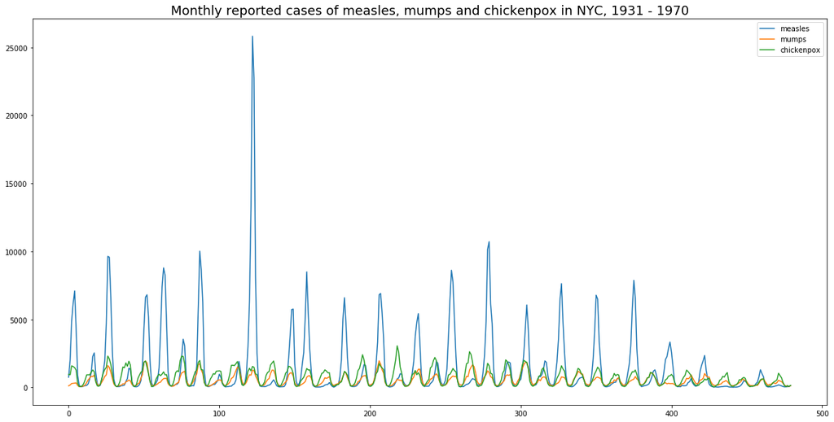

```python
import pandas as pd
import matplotlib.pyplot as plt
data = pd.read_csv('nyc_data.csv')

plt.figure(figsize=(20,10))
plt.title('Monthly reported cases of measles, mumps and chickenpox in NYC, 1931 - 1970', fontsize=18)
plt.plot(data.measles, label='measles')
plt.plot(data.mumps, label='mumps')
plt.plot(data.chickenpox, label='chickenpox')
plt.legend()
plt.show()
```

# Hypotheses and success metrics

### Hypothesis 1: There is a relationship between these diseases - they will tend to vary together

#### Success Metrics:

- Examine potential relationships between these series, including correlation
- Examine potential relationships between these series and other factors (weather, school vs summer, ?)

### Hypothesis 2: We can predict the volume of "future" reported cases for these diseases

#### Success Metrics:

- Time series forecast for at least 1 of these diseases - predicting monthly reported cases for 1971

# Risks or limitations

- Might be difficult to find complementary datasets from this time period
- Might require the "layering" of forecasts
- I don't know anything about infectious diseases!

# Appendix

# Data sets

Monthly reported cases of Measles, Mumps + Chickenpox in NYC (1928/31 - 1972):

- https://datamarket.com/data/set/22z3/monthly-reported-number-of-cases-of-measles-new-york-city-1928-1972#!ds=22z3&display=line
- https://datamarket.com/data/set/22st/monthly-reported-number-of-cases-of-mumps-new-york-city-1928-1972#!ds=22st&display=line
- https://datamarket.com/data/set/22v7/monthly-reported-number-of-chickenpox-new-york-city-1931-1972#!ds=22v7&display=line

Note: The data was first published in: Yorke, J.A. and London, W.P. (1973). "Recurrent Outbreaks of Measles, Chickenpox and Mumps", American Journal of Epidemiology, Vol. 98, pp. 469.